# Stats 769 Lab 7

```r
library(MASS)
library(tree)
library(parallel)
```

# Introduction

1. In your own words, describe briefly the data sets and the practical problems that are associated with them.

For regression, a dataset of home values in Boston, Massachusetts USA which includes demographic information is used. Of note is the age of the dataset - the original source was published in the 1970’s, so home prices are much lower than one would expect from a modern dataset, due to the influence of decades of inflation.

For classification, 16x16 grayscale images of handwritten digits are used to classify into their appropriate number. Classification of this dataset is known to be difficult, with a 2.5% error rate being considered excellent performance.

# Regression Trees

2. Fit an unpruned regression tree (using mindev=0.005) to the Boston data and plot it (as clearly as you can, by adjusting the dimension of the diagram in your R Markdown file).

```r
summary(Boston)
```

```
##       crim                zn             indus            chas
##  Min.   : 0.00632   Min.   :  0.00   Min.   : 0.46   Min.   :0.00000
##  1st Qu.: 0.08205   1st Qu.:  0.00   1st Qu.: 5.19   1st Qu.:0.00000
##  Median : 0.25651   Median :  0.00   Median : 9.69   Median :0.00000
##  Mean   : 3.61352   Mean   : 11.36   Mean   :11.14   Mean   :0.06917
##  3rd Qu.: 3.67708   3rd Qu.: 12.50   3rd Qu.:18.10   3rd Qu.:0.00000
##  Max.   :88.97620   Max.   :100.00   Max.   :27.74   Max.   :1.00000
##       nox               rm             age              dis
##  Min.   :0.3850   Min.   :3.561   Min.   :  2.90   Min.   : 1.130
##  1st Qu.:0.4490   1st Qu.:5.886   1st Qu.: 45.02   1st Qu.: 2.100
##  Median :0.5380   Median :6.208   Median : 77.50   Median : 3.207
##  Mean   :0.5547   Mean   :6.285   Mean   : 68.57   Mean   : 3.795
##  3rd Qu.:0.6240   3rd Qu.:6.623   3rd Qu.: 94.08   3rd Qu.: 5.188
##  Max.   :0.8710   Max.   :8.780   Max.   :100.00   Max.   :12.127
##       rad              tax           ptratio          black
##  Min.   : 1.000   Min.   :187.0   Min.   :12.60   Min.   :  0.32
##  1st Qu.: 4.000   1st Qu.:279.0   1st Qu.:17.40   1st Qu.:375.38
##  Median : 5.000   Median :330.0   Median :19.05   Median :391.44
##  Mean   : 9.549   Mean   :408.2   Mean   :18.46   Mean   :356.67
##  3rd Qu.:24.000   3rd Qu.:666.0   3rd Qu.:20.20   3rd Qu.:396.23
##  Max.   :24.000   Max.   :711.0   Max.   :22.00   Max.   :396.90
##      lstat            medv
##  Min.   : 1.73   Min.   : 5.00
##  1st Qu.: 6.95   1st Qu.:17.02
##  Median :11.36   Median :21.20
##  Mean   :12.65   Mean   :22.53
##  3rd Qu.:16.95   3rd Qu.:25.00
##  Max.   :37.97   Max.   :50.00
```

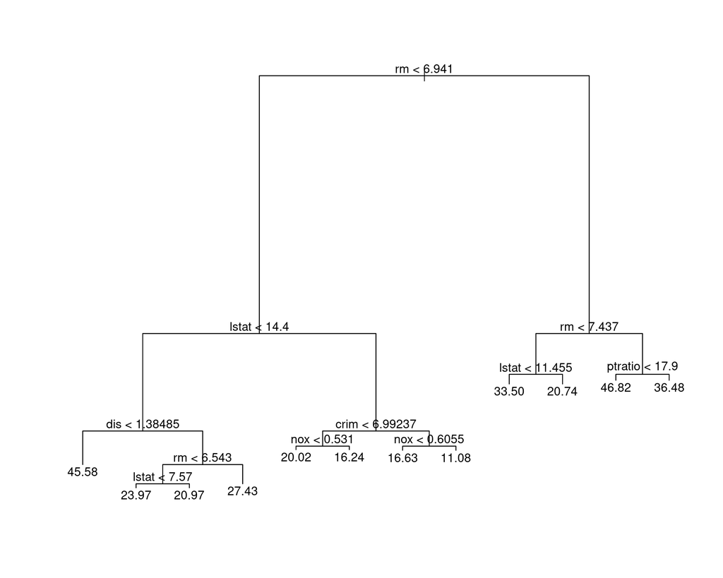

```r
reg <- tree(medv ~ ., data=Boston, mindev=0.005)
plot(reg)
text(reg, pretty=0)
```

Identify the four most important splits in the unpruned tree, and explain why they are.

```r
top4inds <- rev(order(reg$frame$dev))[1:4]
as.matrix(reg$frame[top4inds, c(1,5)])
```

```
##   var     splits.cutleft splits.cutright
## 1 "rm"    "<6.941"       ">6.941"
## 2 "lstat" "<14.4"        ">14.4"
## 4 "dis"   "<1.38485"     ">1.38485"
## 3 "rm"    "<7.437"       ">7.437"
```

The four most important splits in the unpruned tree are:

- rm < 6.941
- lstat < 14.4
- dis < 1.38485
- rm < 7.437

Their relative importance can also be identified in the dendrogram by locating the longest vertical distances after split. They are most important because they reduce the variation (or deviance) in the resulting subsets; After each of those splits, the separated subsets are much more self-similar than the single set where they were unified.

3. Find the solutions to the following questions from the unpruned tree (without using code).

```r
reg
```

```
## node), split, n, deviance, yval
##       * denotes terminal node
##
##  1) root 506 42720.0 22.53
##    2) rm < 6.941 430 17320.0 19.93
##      4) lstat < 14.4 255  6632.0 23.35
##        8) dis < 1.38485 5   390.7 45.58 *
##        9) dis > 1.38485 250  3721.0 22.91
##         18) rm < 6.543 195  1636.0 21.63
##           36) lstat < 7.57 43   129.6 23.97 *
##           37) lstat > 7.57 152  1204.0 20.97 *
##         19) rm > 6.543 55   643.2 27.43 *
##      5) lstat > 14.4 175  3373.0 14.96
##       10) crim < 6.99237 101  1151.0 17.14
##         20) nox < 0.531 24   216.4 20.02 *
##         21) nox > 0.531 77   672.5 16.24 *
##       11) crim > 6.99237 74  1086.0 11.98
##         22) nox < 0.6055 12   223.3 16.63 *
##         23) nox > 0.6055 62   552.3 11.08 *
##    3) rm > 6.941 76  6059.0 37.24
##      6) rm < 7.437 46  1900.0 32.11
##       12) lstat < 11.455 41   844.2 33.50 *
##       13) lstat > 11.455 5   329.8 20.74 *
##      7) rm > 7.437 30  1099.0 45.10
##       14) ptratio < 17.9 25   340.7 46.82 *
##       15) ptratio > 17.9 5   312.7 36.48 *
```

1. What is the variation (TSS) reduction by the split at the root node?
- The variation reduction by the first split rm < 6.941 is difference in deviance of the unified dataset with the sum of deviances of resulting datasets after split. This is given by 42720 - (17320 + 6059) = 19341.
2. What is the predicted response value by the tree for the following observation?

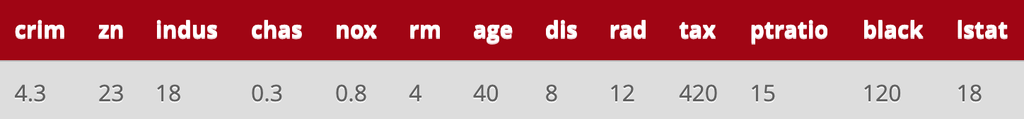

By following the tree’s prescribed splits on this observation, we can derive the predicted value. The tree sends the observation to the:

- left at node 2, as `4 < 6.941`
- right at node 5, as `18 > 14.4`
- left at node 10, as `4.3 < 6.99237`
- right at node 21, as `0.8 > 0.531`

This lands the observation in leaf node 21 which predicts a `medv` median home value of 16.24 (in 1,000’s USD).

3. In which hyper-rectangular “region”, the median value of owner-occupied homes is the highest?
- Of all possible median home prices predicted by the model, 46.82 is highest, at node 14. This node is associated with the hyper-rectanglar region where `rm > 6.941`, `rm > 7.437`, and `ptratio < 17.9`.
4. Find the best pruned tree of size 5.

Does this tree contain the most important splits you chose earlier? Describe when the best pruned tree of size k must contain the (k-1) most important splits. Provide your reasoning.

```r
(best5 <- prune.tree(reg, best=5))
```

```
## node), split, n, deviance, yval
##       * denotes terminal node
##
## 1) root 506 42720.0 22.53
##   2) rm < 6.941 430 17320.0 19.93
##     4) lstat < 14.4 255  6632.0 23.35
##       8) dis < 1.38485 5   390.7 45.58 *
##       9) dis > 1.38485 250  3721.0 22.91 *
##     5) lstat > 14.4 175  3373.0 14.96 *
##   3) rm > 6.941 76  6059.0 37.24
##     6) rm < 7.437 46  1900.0 32.11 *
##     7) rm > 7.437 30  1099.0 45.10 *
```

- This tree does contain the most important splits from the unpruned tree. Maintaining the k-1 most important splits in a tree of size k should always hold true if the tree is pruned based on size. It is possible that pruning using cost-complexity would yield different splits, however.
5. Find the pruned tree, based on 10-fold cross-validation (just 1 repetition), and plot it (as clearly as you can).

```r
set.seed(123)
cv.reg <- cv.tree(reg, K=10)
(bestK <- cv.reg$size[which.min(cv.reg$dev)])
```

```
## [1] 12
```

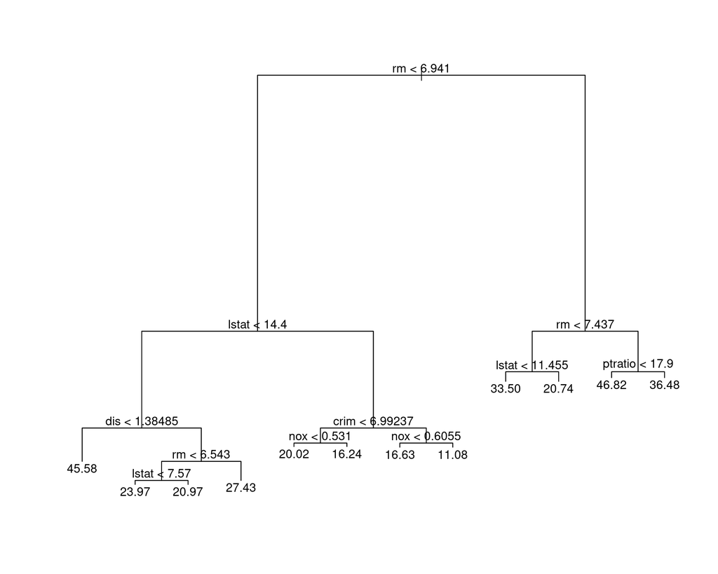

```r
best.reg <- prune.tree(reg, best=bestK)
plot(best.reg)
text(best.reg, pretty=0)
```

# Classification trees

For the problems below that concern classification, use the two USPS data sets. Make sure that the response variable digit is a factor. An error mentioned below means a misclassification rate.

```r
ziptrain <- read.csv("ziptrain.csv")
ziptrain$digit <- as.factor(ziptrain$digit)

ziptest <- read.csv("ziptest.csv")
ziptest$digit <- as.factor(ziptest$digit)
```

6. Grow an unpruned tree that fits the training data perfectly. (No need to plot it, as it may be quite large).

Consider pruning this tree using the cost-complexity criterion in terms of deviance/entropy. Find the (training) deviance values of all the trees in the sequence of nested trees. Must these values be monotone with the size of the tree? Explain why.

```r
c <- tree(digit ~ ., data=ziptrain, mindev=0.001)
p <- prune.tree(c, method="deviance")
p$dev
```

```
##   [1]  3827.338  3861.217  3895.667  3930.154  3964.771  4034.228  4068.973
##   [8]  4104.012  4139.391  4174.977  4210.996  4247.254  4283.735  4321.289
##  [15]  4358.950  4396.646  4435.175  4473.729  4512.305  4589.652  4628.921
##  [22]  4668.234  4709.002  4749.815  4790.783  4832.312  4874.450  4916.747
##  [29]  4960.083  5005.441  5051.897  5098.477  5147.291  5196.307  5246.494
##  [36]  5297.334  5348.201  5399.130  5450.443  5502.137  5556.015  5612.644
##  [43]  5671.623  5734.968  5802.099  5870.528  5939.066  6008.137  6077.577
##  [50]  6149.604  6222.468  6295.369  6368.710  6442.293  6519.232  6597.298
##  [57]  6675.526  6758.754  6843.801  6932.155  7020.994  7109.910  7199.641
##  [64]  7290.186  7381.562  7476.687  7575.217  7674.157  7783.299  7900.713
##  [71]  8031.017  8177.180  8480.322  8640.568  8803.938  8969.008  9135.699
##  [78]  9320.005  9507.260  9706.251  9944.237 10218.121 10492.732 10778.380
##  [85] 11069.344 11425.003 12150.050 12514.826 12893.545 13347.966 13900.037
##  [92] 14494.609 15270.018 16148.235 17188.173 18503.393 19953.866 21585.056
##  [99] 24157.188 26743.733 33095.321
```

```r
cat("Monotonic:", all(seq_along(p$dev) == order(p$dev)))
```

```
## Monotonic: TRUE
```

- The deviance of each successively pruned tree is always monotonic with respect to the training data. The cost-complexity criterion, for fixed k, is linear with respect to the size of the tree, so each reduction in tree size must reduce the complexity. This necessarily increases the deviance of the resulting tree with respect to the training data, as the model is not able to fit as tightly, but it is hoped to reduce the deviance with respect to the test data.
7. Consider pruning the unpruned tree obtained in Question 6, using the cost-complexity criterion in terms of deviance.

Find both the training and test errors of all the nested trees in the sequence. Show both error curves versus the size of the tree in one graph.

(There is a small bug in prune.tree(). When the tree size is 1, it returns an object of class singlenode, rather than an object of class tree, and thus predict.tree() cannot be used in this case. A simple solution is to set the output of prune.tree() when the tree size is 1 to class tree, by using the class function.)

```r
prediction <- function(tree, data, size) {
    pruned <- prune.tree(tree, best=size)
    if (class(pruned) != "tree") class(pruned) <- "tree"
    predict(pruned, data, type="class")
}
```

```r
trainErrs <- sapply(p$size, function(x) {mean(prediction(c, ziptrain, x) != ziptrain$digit)})
```

```r
testErrs <- sapply(p$size, function(x) {mean(prediction(c, ziptest, x) != ziptest$digit)})
```

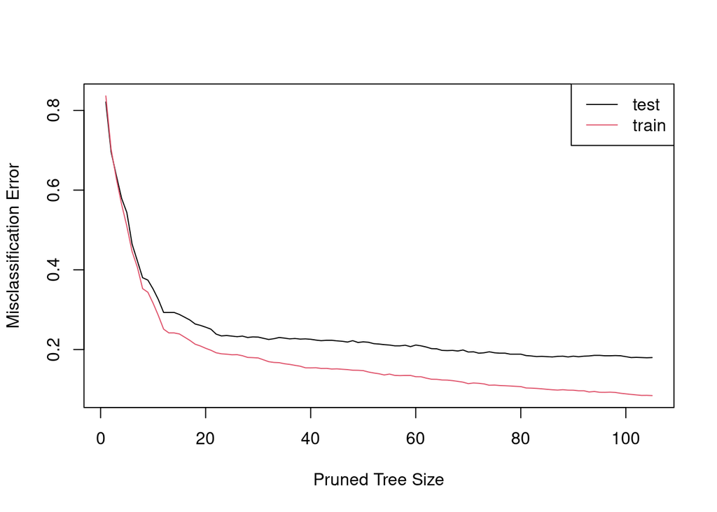

```r
m <- cbind(testErrs, trainErrs)
matplot(x=p$size, y=m, type='l', lty=1, xlab="Pruned Tree Size",
        ylab="Misclassification Error")
legend("topright", legend=c("test","train"), col=1:2, lty=1)
```

8. Consider pruning the tree using 10-fold cross-validation with 20 repetitions (in aid of parallel computing using 20 cores) for the purpose of minimising the deviance. What are the training and test errors of the resulting (smallest) pruned tree?

```r
mc.cv <- function(seed, ...) {
    set.seed(seed)
    cv.c <- cv.tree(c, ...)
    # reverse size and dev to get smallest tree of those with min dev
    best <- rev(cv.c$size)[which.min(rev(cv.c$dev))]
    trainerr <- mean(prediction(c, ziptrain, best) != ziptrain$digit)
    testerr <- mean(prediction(c, ziptest, best) != ziptest$digit)
    c(best, trainerr, testerr)
}

get_best <- function(method, reps=20) {
    cv.dev <- matrix(unlist(mclapply(X=1:reps*reps, FUN=mc.cv,
                                     method=method, mc.cores=20)),
                     ncol=3, byrow=T)
    colnames(cv.dev) <- c("size", "train_err", "test_err")
    lowest_err <- cv.dev[cv.dev[,3] == min(cv.dev[,3]),]
    if (class(lowest_err)[1] == "numeric") lowest_err
    else lowest_err[which.min(lowest_err[,1]),]
}

get_best(method="deviance")
```

```
##       size  train_err   test_err
## 18.0000000  0.2134138  0.2640757
```

9. Consider pruning the tree using 10-fold cross-validation with 20 repetitions (in aid of parallel computing using 20 cores) for the purpose of minimising the misclassification rate. What are the training and test errors of the resulting (smallest) pruned tree?

```r
get_best(method="misclass")
```

```
##       size  train_err   test_err
## 63.0000000  0.1259087  0.2017937
```

# Summary

In this report, regression and classification trees are used to predict home prices and handwritten digits, respectively. The tradeoffs of pruning methods are explored, and parallelised cross-validation is used to choose a model which both minimises prediction error and model size.